# Airplane Crashes and Fatalities

## Introduction

> Introduce the dataset

## Preliminary Wrangling

```python
# import all packages and set plots to be embedded inline
import numpy as np
import pandas as pd
import matplotlib.pyplot as plt
import seaborn as sns
from IPython import display
%matplotlib inline
```

> Load in your dataset and describe its properties through the questions below. Try and motivate your exploration goals through this section.

```python
df1 = pd.read_csv("Airplane_Crashes_and_Fatalities_Since_1908_20190820105639.csv")
```

```python
df1.sample(3)
```

|  | Date | Time | Location | Operator | Flight # | Route | AC Type | Registration | cn/ln | Aboard | Aboard Passangers | Aboard Crew | Fatalities | Fatalities Passangers | Fatalities Crew | Ground | Summary |
| --- | --- | --- | --- | --- | --- | --- | --- | --- | --- | --- | --- | --- | --- | --- | --- | --- | --- |
| 679 | 06/16/1943 | NaN | Khartoum, Sudan | British Overseas Airways | NaN | NaN | Lockheed Hudson VI | FK-459 | NaN | 17.0 | NaN | NaN | 17.0 | NaN | NaN | 0.0 | NaN |
| 2416 | 09/14/1969 | 20:33 | Londrina-Parana, Brazil | VASP | NaN | Camp Grande - Londrina - Sao Palo | Douglas DC-3 | PP-SPP | 15618/27063 | 21.0 | 15.0 | 6.0 | 20.0 | 15.0 | 5.0 | 0.0 | Fifteen minutes after leaving Londina, the por... |
| 4273 | 08/06/2000 | 15:55 | Puerto Montt, Chile | Military - Fuerza Aérea de Chile | - | Santiago - Coihaique | Casa 212-AB10 Aviocar | 230 | AB10-454 | 14.0 | 10.0 | 4.0 | 14.0 | 10.0 | 4.0 | 0.0 | The aircraft crashed into a volcano after the ... |

```python
df1.info()
```

```
<class 'pandas.core.frame.DataFrame'>
RangeIndex: 4967 entries, 0 to 4966
Data columns (total 17 columns):
 #   Column                 Non-Null Count  Dtype
---  ------                 --------------  -----
 0   Date                   4967 non-null   object
 1   Time                   3457 non-null   object
 2   Location               4963 non-null   object
 3   Operator               4957 non-null   object
 4   Flight #               1315 non-null   object
 5   Route                  4193 non-null   object
 6   AC Type                4952 non-null   object
 7   Registration           4694 non-null   object
 8   cn/ln                  4299 non-null   object
 9   Aboard                 4949 non-null   float64
 10  Aboard Passangers      4738 non-null   float64
 11  Aboard Crew            4741 non-null   float64
 12  Fatalities             4959 non-null   float64
 13  Fatalities Passangers  4725 non-null   float64
 14  Fatalities Crew        4726 non-null   float64
 15  Ground                 4926 non-null   float64
 16  Summary                4903 non-null   object
dtypes: float64(7), object(10)
memory usage: 659.8+ KB
```

> Date and Time in separate columns and of object time.Need to be combined to create a datetime column

```python
df1.shape
```

```
(4967, 17)
```

```python
sum(df1.duplicated())
```

```
0
```

> No duplicates

```python
df1.isnull().sum()
```

```
Date                        0
Time                     1510
Location                    4
Operator                   10
Flight #                 3652
Route                     774
AC Type                    15
Registration              273
cn/ln                     668
Aboard                     18
Aboard Passangers         229
Aboard Crew               226
Fatalities                  8
Fatalities Passangers     242
Fatalities Crew           241
Ground                     41
Summary                    64
dtype: int64
```

> Time column has a lot of missing values. However dropping it will not be considered because it will be combined with the Date column. Interpolation will be used to fill in the missing values and the rest can be filled in with a forward fill.  
> flight number,cn/ln and registration columns can be dropped as they will not be used to derive any insights

```python
df1.describe()
```

|  | Aboard | Aboard Passangers | Aboard Crew | Fatalities | Fatalities Passangers | Fatalities Crew | Ground |
| --- | --- | --- | --- | --- | --- | --- | --- |
| count | 4949.000000 | 4738.000000 | 4741.000000 | 4959.000000 | 4725.000000 | 4726.000000 | 4926.000000 |
| mean | 31.088301 | 26.898691 | 4.479646 | 22.338173 | 19.017566 | 3.579348 | 1.728177 |
| std | 45.438282 | 44.010591 | 3.489021 | 35.026176 | 34.114849 | 3.170223 | 55.708966 |
| min | 0.000000 | 0.000000 | 0.000000 | 0.000000 | 0.000000 | 0.000000 | 0.000000 |
| 25% | 7.000000 | 3.000000 | 2.000000 | 4.000000 | 1.000000 | 2.000000 | 0.000000 |
| 50% | 16.000000 | 12.000000 | 4.000000 | 11.000000 | 8.000000 | 3.000000 | 0.000000 |
| 75% | 35.000000 | 30.000000 | 6.000000 | 25.000000 | 21.000000 | 5.000000 | 0.000000 |
| max | 644.000000 | 614.000000 | 61.000000 | 583.000000 | 560.000000 | 46.000000 | 2750.000000 |

```python
qualitative = (df1.select_dtypes('object')).columns
df1[qualitative].describe()
```

|  | Date | Time | Location | Operator | Flight # | Route | AC Type | Registration | cn/ln | Summary |
| --- | --- | --- | --- | --- | --- | --- | --- | --- | --- | --- |
| count | 4967 | 3457 | 4963 | 4957 | 1315 | 4193 | 4952 | 4694 | 4299 | 4903 |
| unique | 4539 | 1062 | 4101 | 2242 | 883 | 3800 | 2447 | 4661 | 3869 | 4808 |
| top | 08/31/1988 | 15:00 | Moscow, Russia | Aeroflot | - | Training | Douglas DC-3 | 49 | 1 | Crashed under unknown circumstances. |
| freq | 4 | 37 | 17 | 255 | 36 | 92 | 333 | 3 | 8 | 9 |

```python
df = df1.copy() # All changes will be made on the copy
```

```python
df.drop(columns=['Flight #','Registration','cn/ln'], inplace = True)
```

> In trying to convert the Time column to datetime format, it appears to have outlier values. To better understand this, all values will be converted to floats by replacing the ':' with a '.'

```python
df['time'] = df['Time'].str.replace(':','.').astype(float) # Turning it into a float for easier manipulation
df['time'].interpolate(method ='linear', limit_direction ='backward',inplace=True) # Filling all missing values
df['time'].describe() # Examining for outliers
```

```
count    4967.000000
mean       12.955772
std         5.831512
min         0.000000
25%         9.189000
50%        13.172500
75%        17.200000
max        91.500000
Name: time, dtype: float64
```

> Time should not exceed 24 hours, so the 91 is definitely an outlier.

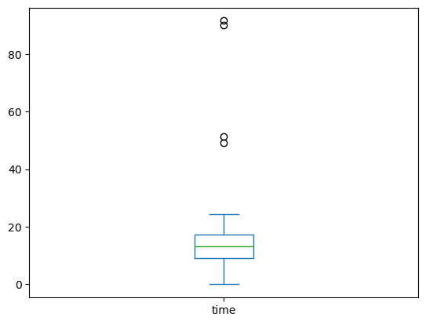

```python
df['time'].plot(kind='box'); # Checking for more outliers
```

```python
# Since a day only has 24 hours, it is logical for anything outside of this to be an outlier.
# Dropping all values past the 24th mark.
df = df[df['time'] < 24.0]
```

```python
df['time'].describe() # confirming changes
```

```
count    4962.000000
mean       12.907042
std         5.568583
min         0.000000
25%         9.182000
50%        13.165000
75%        17.189167
max        23.590000
Name: time, dtype: float64
```

```python
df.fillna(method="ffill",inplace = True ) # filling all remaining missing values before further manipulation
```

```python
df.isnull().sum() #confirming changes
```

```
Date                     0
Time                     0
Location                 0
Operator                 0
Route                    0
AC Type                  0
Aboard                   0
Aboard Passangers        0
Aboard Crew              0
Fatalities               0
Fatalities Passangers    0
Fatalities Crew          0
Ground                   0
Summary                  0
time                     0
dtype: int64
```

```python
#Breaking the 24 hours into 4 groups
df['time_of_day'] = pd.cut(df['time'], bins = [00.00,06.00,12.00,18.00,24.00], labels = ['Night', 'Morning', 'Afternoon', 'Evening'], right = False)
```

```python
# Working towards creating a datetime column
df['time'] = df['time'].astype('object')
df['time'] = df['Time'].str.replace('.',':')
df['date_time'] = df.Date + " " + df.time
df['date_time'] = pd.to_datetime(df['date_time'])
```

```python
df['year'] = df['date_time'].dt.year # The number of years exceeds 100, hence visualizing each date would be a little messy.
df['month'] = df['date_time'].dt.month #We can create seasons from this.
```

```python
def find_season(month, hemisphere):
    if hemisphere == 'Northern':
        season_month_north = {
            12:'Winter', 1:'Winter', 2:'Winter',
            3:'Spring', 4:'Spring', 5:'Spring',
            6:'Summer', 7:'Summer', 8:'Summer',
            9:'Autumn', 10:'Autumn', 11:'Autumn'}
        return season_month_north.get(month)

season_list = []
hemisphere = 'Northern'
for month in df['month']:
    season = find_season(month, hemisphere)
    season_list.append(season)

df['Season'] = season_list

#Reference : https://allanbond.medium.com/creating-a-function-to-convert-a-month-number-to-the-season-a40237966ef3
```

```python
df['Season'] = df['Season'].astype('category')
```

```python
df['month'] = df['month'].replace({1: 'January', 2: 'February', 3: 'March', 4: 'April', 5:'May',6:'June',7:'July',8:'August',9:'September',10:'October',11:'November',12:'December'})
```

```python
df.drop(columns=['time'], inplace = True) # we can now drop this column we will no longer be using it.
```

```python
#Creating a column to acertain degree fatality
df['Fatalities_degree'] = pd.cut(df['Fatalities'], bins = [0.0,5.0,10.0,20.0,50.0,100.0,584.0], labels = ["0-5 Fatalities", "5-10 Fatalities","10-20 Fatalities","20-50 Fatalities","50-100 Fatalities","Greater than 100 Fatalities"],right = False)
```

```python
df.head()
```

|  | Date | Time | Location | Operator | Route | AC Type | Aboard | Aboard Passangers | Aboard Crew | Fatalities | Fatalities Passangers | Fatalities Crew | Ground | Summary | time_of_day | date_time | year | month | Season | Fatalities_degree |
| --- | --- | --- | --- | --- | --- | --- | --- | --- | --- | --- | --- | --- | --- | --- | --- | --- | --- | --- | --- | --- |
| 0 | 09/17/1908 | 17:18 | Fort Myer, Virginia | Military - U.S. Army | Demonstration | Wright Flyer III | 2.0 | 1.0 | 1.0 | 1.0 | 1.0 | 0.0 | 0.0 | During a demonstration flight, a U.S. Army fly... | Afternoon | 1908-09-17 17:18:00 | 1908 | September | Autumn | 0-5 Fatalities |
| 1 | 09/07/1909 | 17:18 | Juvisy-sur-Orge, France | Military - U.S. Army | Air show | Wright Byplane | 1.0 | 0.0 | 1.0 | 1.0 | 0.0 | 0.0 | 0.0 | Eugene Lefebvre was the first pilot to ever be... | Morning | 1909-09-07 17:18:00 | 1909 | September | Autumn | 0-5 Fatalities |
| 2 | 07/12/1912 | 06:30 | Atlantic City, New Jersey | Military - U.S. Navy | Test flight | Dirigible | 5.0 | 0.0 | 5.0 | 5.0 | 0.0 | 5.0 | 0.0 | First U.S. dirigible Akron exploded just offsh... | Morning | 1912-07-12 06:30:00 | 1912 | July | Summer | 5-10 Fatalities |
| 3 | 08/06/1913 | 06:30 | Victoria, British Columbia, Canada | Private | Test flight | Curtiss seaplane | 1.0 | 0.0 | 1.0 | 1.0 | 0.0 | 1.0 | 0.0 | The first fatal airplane accident in Canada oc... | Afternoon | 1913-08-06 06:30:00 | 1913 | August | Summer | 0-5 Fatalities |
| 4 | 09/09/1913 | 18:30 | Over the North Sea | Military - German Navy | Test flight | Zeppelin L-1 (airship) | 20.0 | 0.0 | 1.0 | 14.0 | 0.0 | 1.0 | 0.0 | The airship flew into a thunderstorm and encou... | Evening | 1913-09-09 18:30:00 | 1913 | September | Autumn | 10-20 Fatalities |

```python
df.info()
```

```
<class 'pandas.core.frame.DataFrame'>
Int64Index: 4962 entries, 0 to 4966
Data columns (total 20 columns):
 #   Column                 Non-Null Count  Dtype
---  ------                 --------------  -----
 0   Date                   4962 non-null   object
 1   Time                   4962 non-null   object
 2   Location               4962 non-null   object
 3   Operator               4962 non-null   object
 4   Route                  4962 non-null   object
 5   AC Type                4962 non-null   object
 6   Aboard                 4962 non-null   float64
 7   Aboard Passangers      4962 non-null   float64
 8   Aboard Crew            4962 non-null   float64
 9   Fatalities             4962 non-null   float64
 10  Fatalities Passangers  4962 non-null   float64
 11  Fatalities Crew        4962 non-null   float64
 12  Ground                 4962 non-null   float64
 13  Summary                4962 non-null   object
 14  time_of_day            4962 non-null   category
 15  date_time              4962 non-null   datetime64[ns]
 16  year                   4962 non-null   int64
 17  month                  4962 non-null   object
 18  Season                 4962 non-null   category
 19  Fatalities_degree      4962 non-null   category
dtypes: category(3), datetime64[ns](1), float64(7), int64(1), object(8)
memory usage: 712.9+ KB
```

```python
df.shape
```

```
(4962, 20)
```

### What is the structure of your dataset?

> 4962 instances and 20 variables

### What is/are the main feature(s) of interest in your dataset?

> Main interest is the fatalities count.

### What features in the dataset do you think will help support your investigation into your feature(s) of interest?

> Year, time_of_day, month, season and aboard

## Univariate Exploration

### What are the reasons behind plane crash accidents?

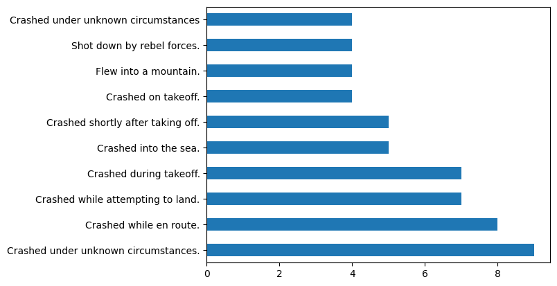

```python
df['Summary'].value_counts().head(10).plot(kind = 'barh')
```

> Using the Summary column minus manipulation does not share much meaningful insight as certain reasons seem to repeated using different wording. Some transformations will be performed on the column such as setting everything to lower case and taking out individual words.

```python
df["reasons"] = df['Summary'].str.lower().str.replace('[^\w\s]','')


new_df = df.reasons.str.split(expand=True).stack().value_counts().reset_index()

new_df.columns = ['Word', 'Frequency']

new_df.head()

# Reference https://predictivehacks.com/?all-tips=word-counts-in-pandas-data-frames
```

|  | Word | Frequency |
| --- | --- | --- |
| 0 | the | 18213 |
| 1 | of | 5455 |
| 2 | a | 5421 |
| 3 | and | 5395 |
| 4 | to | 5389 |

```python
#Tons pf experimenting and manual search
new_df.iloc[5:40]
new_df.iloc[40:60]
new_df.iloc[60:80]
new_df.iloc[80:100]
```

|  | Word | Frequency |
| --- | --- | --- |
| 80 | one | 299 |
| 81 | low | 298 |
| 82 | pilots | 293 |
| 83 | out | 291 |
| 84 | area | 286 |
| 85 | caused | 280 |
| 86 | its | 275 |
| 87 | terrain | 275 |
| 88 | minutes | 273 |
| 89 | about | 265 |
| 90 | power | 261 |
| 91 | sea | 258 |
| 92 | descent | 239 |
| 93 | he | 239 |
| 94 | heavy | 238 |
| 95 | trees | 238 |
| 96 | below | 237 |
| 97 | captain | 236 |
| 98 | his | 235 |
| 99 | before | 226 |

```python
#Searching for word context, manual search
pd.set_option('display.max_colwidth', 500)
df["Summary"].loc[df["Summary"].str.contains("engine", case=False, na=False)].head()
```

```
5     Hydrogen gas which was being vented was sucked into the forward engine and ignited causing the airship to explode and burn at 3,000 ft..
38                                                                  The aircraft suffered engine failure and crashed shortly after taking off.
39                                                       Crashed while taking off after engine failure. Engine failure due to fuel exhaustion.
43                                               The pilot crashed after attempting to make an emergency landing after the engine caught fire.
50                                                                                     The aircraft stalled and crashed when an engine failed.
Name: Summary, dtype: object
```

```python
#Creating new dataframe based on word count
#Disclaimer, results are liable to human error
top_10_reason_dict = {"runway accidents":857,
            "engine issues":773,
            "structural failure":708,
            "landing gone wrong":611,
            "poor weather":488,
            "loss of control":479,
            "takeoff accidents":427,
            "Crashed while en route":309,
            "ran out of fuel":274,"Pilot error":271}

reasons = pd.DataFrame(list(top_10_reason_dict.items()), columns = ['Plane crash reason','Frequency'])
reasons
```

|  | Plane crash reason | Frequency |
| --- | --- | --- |
| 0 | runway accidents | 857 |
| 1 | engine issues | 773 |
| 2 | structural failure | 708 |
| 3 | landing gone wrong | 611 |
| 4 | poor weather | 488 |
| 5 | loss of control | 479 |
| 6 | takeoff accidents | 427 |
| 7 | Crashed while en route | 309 |
| 8 | ran out of fuel | 274 |
| 9 | Pilot error | 271 |

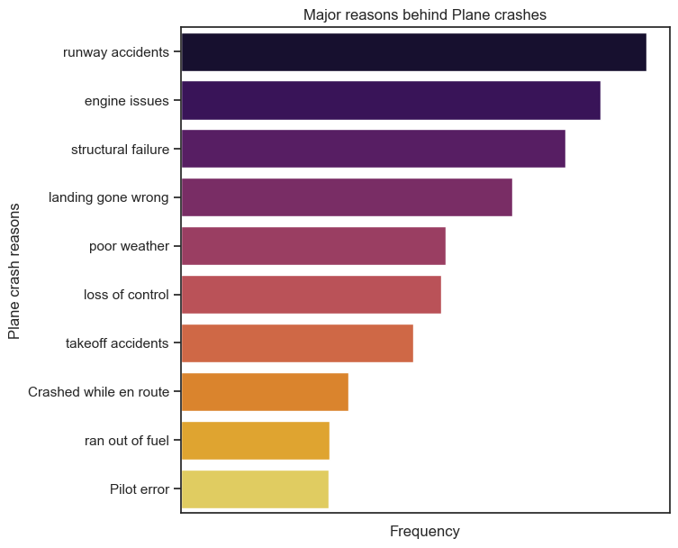

```python
sns.set(rc={'figure.figsize':(7,7)})
sns.set_style('ticks')
ax =sns.barplot(
        data=reasons,
        x = "Frequency",
        y="Plane crash reason",
        palette = 'inferno'
)

ax.set_xlabel('Frequency')
ax.set_ylabel('Plane crash reasons')
ax.set_title('Major reasons behind Plane crashes')
ax.set_xticks([]) #Removing xticks as the quantities are not of accurate measure but approximations

plt.show()
```

> The visualization can not be quantified numerically as several reasons could be associated with one accident. However the color palette is used to show reasons frequency, from most frequent reason to least frequent.

```python
df['all_died'] = (df['Aboard'] == df['Fatalities']) # checking if everyone onboard died
```

### What propotion of individuals died during the plane crashes?

```
''
```

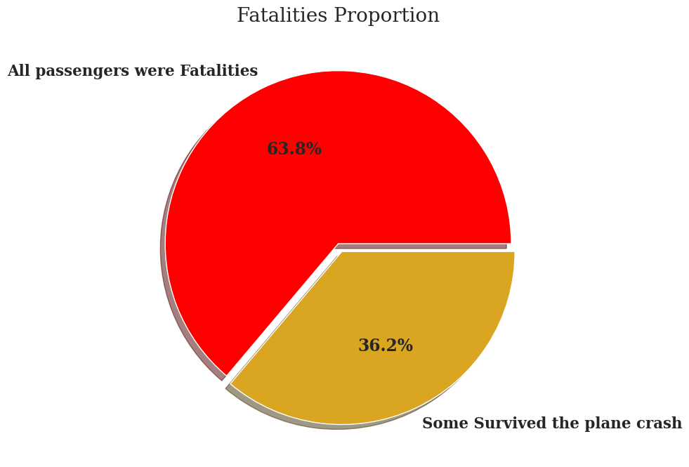

```python
colors = ['red','goldenrod']
labels = ['All passengers were Fatalities','Some Survived the plane crash']
text_props = {"weight": "bold"}
explode = [0,0.05]
fig = plt.figure(figsize=(8, 8))
sns.set(font_scale=1.4)
sns.set_style({'font.family':'serif', 'font.serif':['Times New Roman']})

plt.pie(df['all_died'].value_counts(),colors=colors,autopct='%1.1f%%',labels=labels,textprops=text_props,explode=explode,shadow=True)
plt.title("Fatalities Proportion",fontsize = 20)
;
```

> More than 50% died during plane crash accidents.With survival barely past 35%

### What is the distribution of plane crashes across different times of the day?

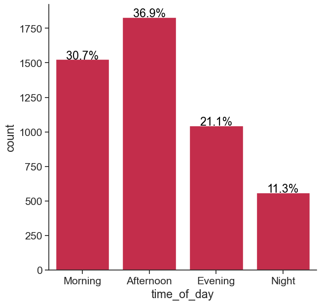

```python
sns.set_style("ticks", {"axes.spines.top": False, "axes.spines.right": False})
total = df['time_of_day'].value_counts().sum()
sns.countplot(data=df, x='time_of_day', color='crimson', order = ['Morning', 'Afternoon', 'Evening', 'Night']);

time_of_day_counts = df['time_of_day'].value_counts()

locs, labels = plt.xticks()

for loc, label in zip(locs, labels):

    count = time_of_day_counts[label.get_text()]
    pct_string = '{:0.1f}%'.format(100*count/total)

    plt.text(loc, count+2, pct_string, ha = 'center', color = 'black')
```

> More accidents appear to occur in the afternoon and tend to decrease as night approaches.

## Bivariate Exploration

#### What has been the distribution of plane crashes over the years?

```
No artists with labels found to put in legend.  Note that artists whose label start with an underscore are ignored when legend() is called with no argument.
```

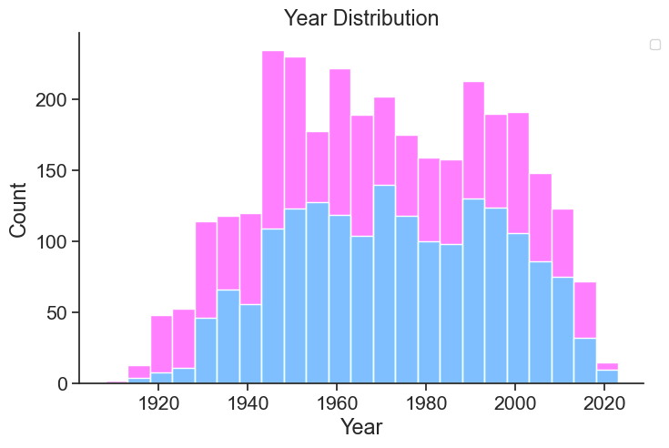

```python
hue_colors = {False:'Aqua',True: 'Fuchsia'}
hue = "all_died"

plt.figure(figsize=(8,5))
bins = np.arange(df['year'].min(), df['year'].max()+5, 5)
sns.histplot(data = df, x = 'year', bins = bins,hue = hue,palette = hue_colors)
plt.legend(bbox_to_anchor=(1, 1), loc='upper left', fontsize=10)
plt.xlabel("Year")
plt.title("Year Distribution")
plt.show()
```

> Generally, it appears to be a bell curve, with the much higher possibility of everyone on board dying.

### Which portions of the day, see accidents claiming everybody on board?

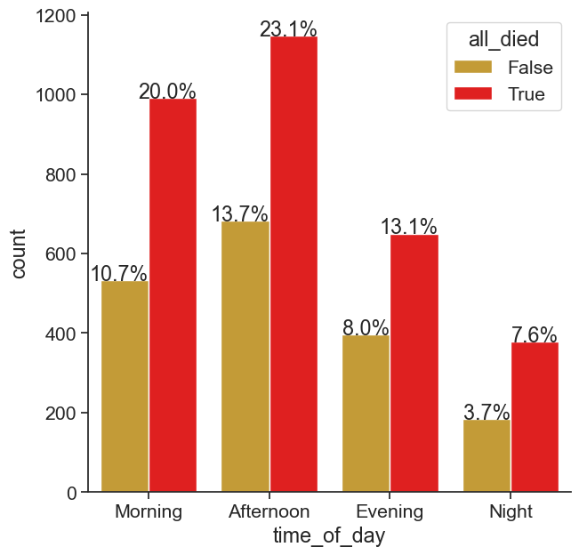

```python
hue_colors = {False:'goldenrod',True: 'red'}
hue = "all_died"
total = float(len(df))

ax = sns.countplot(x='time_of_day', hue=hue, data=df, palette = hue_colors, order = ['Morning', 'Afternoon', 'Evening', 'Night'])
for p in ax.patches:
    percentage = '{:.1f}%'.format(100 * p.get_height()/total)
    x = p.get_x() + p.get_width()
    y = p.get_height()
    ax.annotate(percentage, (x, y),ha='right')
plt.show();
```

> Undoubtedly the Afternoon has the largest proportion

### Is there a correlation between number of passengers on board, fatalities and those who get killed on the ground?

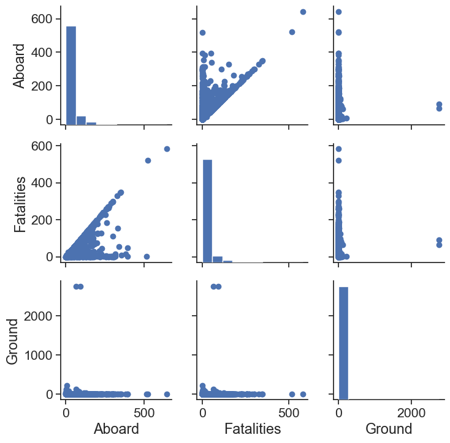

```python
g = sns.PairGrid(data = df, vars = ['Aboard', 'Fatalities', 'Ground'])
g.map_diag(plt.hist)
g.map_offdiag(plt.scatter)
```

- As the numbber of passengers on board increases, so does the number of fatalities. There appears to be a strong positive correlation.
- It appears the vast majority of causualties do not die on the ground.
- The ground also appears to have some outliers.However, due to the fact that there is barely any correlation with fatalities, they will be ignored.

### Confirmation as to whether number killed on the ground does not convey any meaniful message.

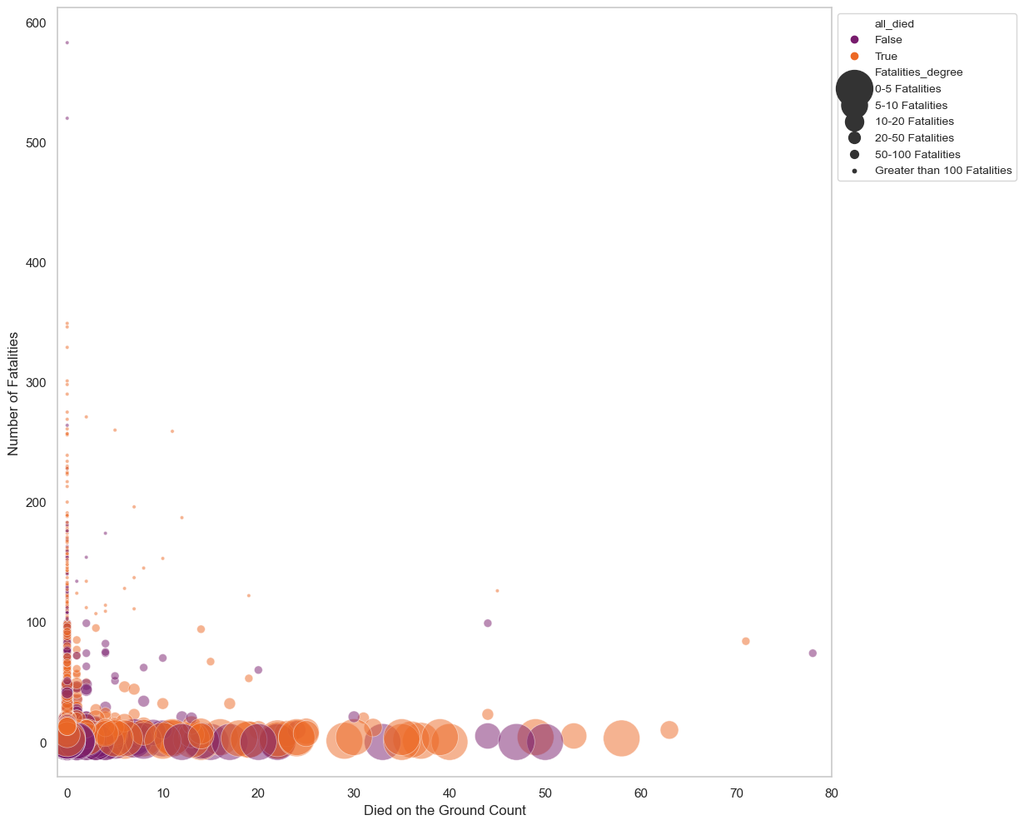

```python
sns.set(rc={'figure.figsize':(12,12)})
sns.set_style("whitegrid",{'axes.grid' : False})

# use the scatterplot function
sns.scatterplot(data=df, x="Ground", y="Fatalities", size="Fatalities_degree", hue="all_died", palette="inferno", edgecolors="black", alpha=0.5, sizes=([1000,500,250,100,50,10]))

# Add titles (main and on axis)
plt.xlabel("Died on the Ground Count")
plt.ylabel("Number of Fatalities")


plt.xlim([-1, 80])
# Locate the legend outside of the plot
plt.legend(bbox_to_anchor=(1, 1), loc='upper left', fontsize=10)

# show the graph
plt.show()
```

> It does appear very small numbers die on the ground.

### What is the general summary? Out of all who were onboard, What percentage were fatalities?

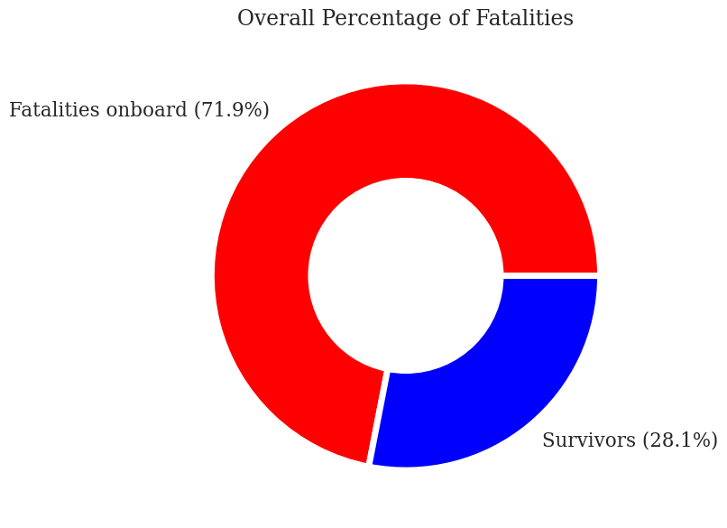

```python
sns.set(font_scale=1.4,rc={'figure.figsize':(20,7)})
sns.set_style({'font.family':'serif', 'font.serif':['Times New Roman']})

#Creating a function we can use to generate donut charts without repetitive code
def fatal_donut(values,names,title):
    my_circle = plt.Circle( (0,0), 0.5, color='white')
    plt.pie(x = values, labels=names,colors=['red','blue'], wedgeprops = { 'linewidth' : 5, 'edgecolor' : 'white' })
    p = plt.gcf()
    p.gca().add_artist(my_circle)
    plt.title(title)
    plt.show()

# Overall summary
all_aboard = df['Aboard'].sum()
total_fatal = df['Fatalities'].sum()
fatal_out_of_aboard = round((total_fatal / all_aboard) * 100, 2)
fatal_out_of_aboard

names = ['Fatalities onboard (71.9%)', 'Survivors (28.1%)']
fatal_out_of_aboard = [71.94,28.06]

overall = fatal_donut(fatal_out_of_aboard,names,"Overall Percentage of Fatalities")
```

> 28.1% Were survivors, this could include people who escaped the accident completely unharmed.

### Which group had a larger proportion of fatalities, the crew or the passengers?¶

```python
# Passenger summary
passenger_aboard = df['Aboard Passangers'].sum()
total_fatal_pass = df['Fatalities Passangers'].sum()
fatal_out_of_aboard_pass = round((total_fatal_pass / passenger_aboard) * 100, 2)
fatal_out_of_aboard_pass

pass_names = ['Passenger Fatalities onboard (70.5%)', 'Survivors (29.5%)'] # for custom annotation
pass_fatal_out_of_aboard = [70.52,29.48]

# Crew summary
crew_aboard = df['Aboard Crew'].sum()
total_fatal_crew = df['Fatalities Crew'].sum()
fatal_out_of_aboard_crew = round((total_fatal_crew / crew_aboard) * 100, 2) # for custom annotation
fatal_out_of_aboard_crew

Crew_names = ['Crew Fatalities onboard (80.2%)', 'Survivors (19.8%)']
crew_fatal_out_of_aboard = [80.23,19.77]
```

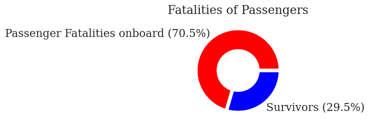

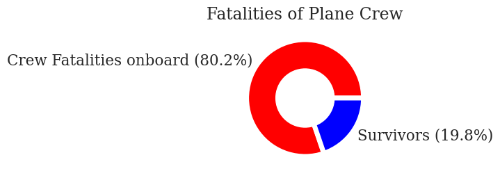

```python
fig = plt.figure(figsize=(6, 6))

plt.subplot(2, 1, 1)
passenger = fatal_donut(pass_fatal_out_of_aboard,pass_names, "Fatalities of Passengers")

fig = plt.figure(figsize=(6, 6))
plt.subplot(2, 1, 2)
crew = fatal_donut(crew_fatal_out_of_aboard,Crew_names,"Fatalities of Plane Crew")

plt.show()
```

> The crew has a 10% higher chance of dying during a plane crash.

### Of the two groups (Crew, Passengers), Which group was more likely to have everybody in the group killed in the plane crash?

```python
passenger = df.groupby(['all_died'])['Fatalities Passangers'].sum().to_frame()
passenger
```

| all_died | Fatalities Passangers |
| --- | --- |
| False | 28999.0 |
| True | 64992.0 |

```python
total_pass_die = 28999.0 + 64992.0
false_percent_pass = round((28999.0 / total_pass_die) * 100,2)
true_percent_pass = round((64992.0 / total_pass_die) * 100,2)
print ("false_die_pass:",false_percent_pass," , ","true_die_pass:",true_percent_pass)

false_percent_pass = str(false_percent_pass) + "%"
true_percent_pass = str(true_percent_pass) + "%"
```

```
false_die_pass: 30.85  ,  true_die_pass: 69.15
```

```python
crew = df.groupby(['all_died'])['Fatalities Crew'].sum().to_frame()
crew
```

| all_died | Fatalities Crew |
| --- | --- |
| False | 4617.0 |
| True | 13341.0 |

```python
total_crew_die = 4617.0 + 13341.0
false_percent_crew = round((4617.0 / total_crew_die) * 100,2)
true_percent_crew = round((13341.0 / total_crew_die) * 100,2)
print ("false_die_crew:",false_percent_crew," , ","true_die_crew:",true_percent_crew)

false_percent_crew = str(false_percent_crew) + "%"
true_percent_crew = str(true_percent_crew) + "%"
```

```
false_die_crew: 25.71  ,  true_die_crew: 74.29
```

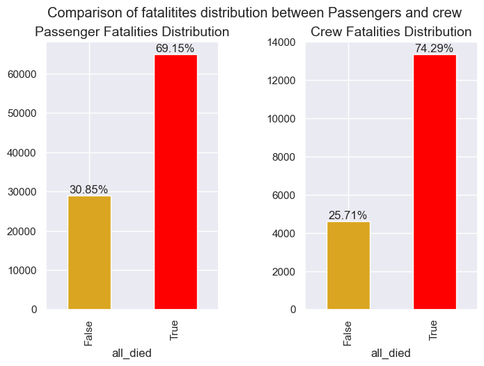

```python
sns.set(font_scale=1)
cmap = ['goldenrod','red']
fig, axes = plt.subplots(1, 2, figsize=(8, 5))
colors = ['red','goldenrod']

df.groupby(['all_died'])['Fatalities Passangers'].sum().plot.bar(
    ax=axes[0], color = cmap
)
for container in axes[0].containers:
    labels = [false_percent_pass,true_percent_pass]
    axes[0].bar_label(container,labels=labels)

axes[0].set_title("Passenger Fatalities Distribution", fontsize=14)

df.groupby(['all_died'])['Fatalities Crew'].sum().plot.bar(
    ax=axes[1], color = cmap
)
for container in axes[1].containers:
    labels = [false_percent_crew,true_percent_crew]
    axes[1].bar_label(container,labels=labels)
axes[1].set_title("Crew Fatalities Distribution", fontsize=14)
plt.subplots_adjust(wspace=.5, hspace=.9)

plt.suptitle("Comparison of fatalitites distribution between Passengers and crew");
```

> Technically there is a very small chance that being a passenger means you are less likely to die as compared to the crew.

### Talk about some of the relationships you observed in this part of the investigation. How did the feature(s) of interest vary with other features in the dataset?

> The is a strong positive correlation between the number of fatalities and the number of passengers on board. However there was barely any correlation between the number of those killed on the ground.

### Did you observe any interesting relationships between the other features (not the main feature(s) of interest)?

> Plane crew members are more likely to wind up as a casualty as compared to the passengers.

## Multivariate Exploration

### Which times of the day, is everybody onboard a plane likely to die, in the event of an accident?

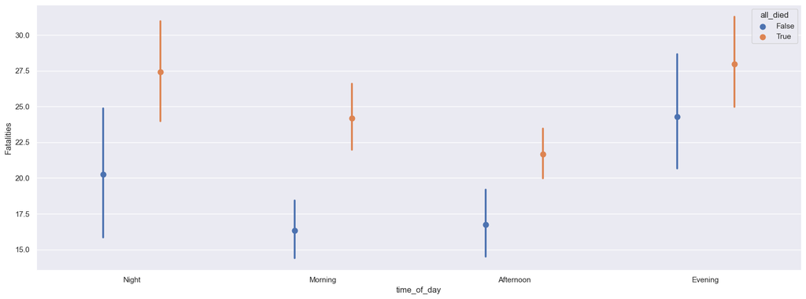

```python
ax = sns.pointplot(data = df, x = 'time_of_day', y = 'Fatalities', hue = 'all_died',
                  dodge = 0.3, linestyles = "")
```

> The evening and night show more casualties but a bar chart will serve a better visual.

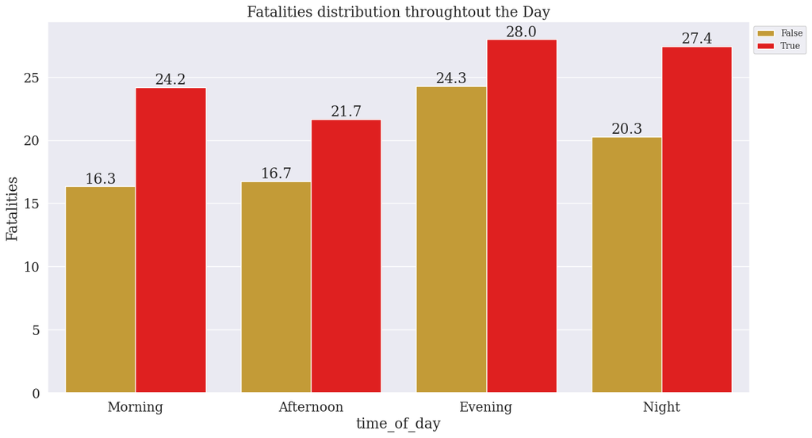

```python
sns.set(font_scale=1.4,rc={'figure.figsize':(15,8)})
sns.set_style({'font.family':'serif', 'font.serif':['Times New Roman']})
hue_colors = {False:'goldenrod',True: 'red'}
ax = sns.barplot(data = df, x = 'time_of_day', y = 'Fatalities', hue = 'all_died',palette = hue_colors, order = ['Morning','Afternoon','Evening','Night'], ci=None)
for container in ax.containers:
    ax.bar_label(container,fmt='%.1f')
plt.legend(bbox_to_anchor=(1, 1), loc='upper left', fontsize=10)
plt.title("Fatalities distribution throughtout the Day");
```

> Despite the countplot showing more accidents in the afternoon, the number of fatalities is highest in the evening.

### What are the numbers associated with different months?

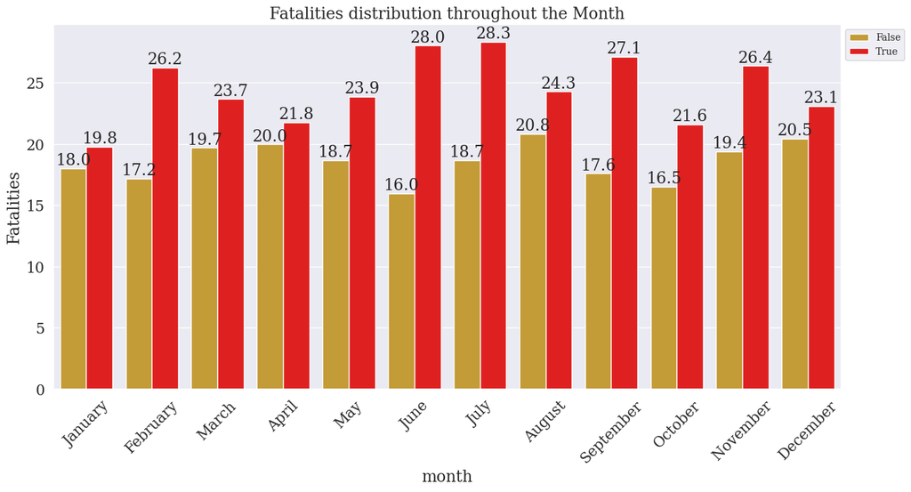

```python
plt.figure(figsize = (15,7))
hue_colors = {False:'goldenrod',True: 'red'}
order = ['January','February','March','April','May','June','July','August','September','October','November','December']
ax = sns.barplot(data = df, x = 'month', y = 'Fatalities', hue = 'all_died',palette = hue_colors, ci=None, order = order)

for container in ax.containers:
    ax.bar_label(container,fmt='%.1f')

plt.legend(bbox_to_anchor=(1, 1), loc='upper left', fontsize=10)
plt.title("Fatalities distribution throughout the Month")
plt.xticks(rotation=45);
```

> The middle months, June and July have high figures. The pattern appears to be polynomial in shape, with fluctuating peaks and troughs.

### What do the seasons show?

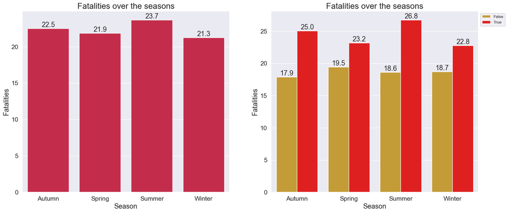

```python
sns.set(font_scale=1.4)
plt.figure(figsize = [20, 8])
plt.subplot(1, 2, 1)

ax = sns.barplot(x= 'Season', y='Fatalities',data = df,color = 'crimson', ci=None )
for container in ax.containers:
    ax.bar_label(container,fmt='%.1f')
plt.title("Fatalities over the seasons",fontsize = 20)

cmap = ['goldenrod','red']
plt.subplot(1, 2, 2)
colors = ['red','goldenrod']
ax = sns.barplot(x= 'Season', y='Fatalities',data = df, hue = 'all_died',palette = hue_colors, ci=None )
for container in ax.containers:
    ax.bar_label(container,fmt='%.1f')
plt.legend(bbox_to_anchor=(1, 1), loc='upper left', fontsize=10)
plt.title("Fatalities over the seasons",fontsize = 20)
plt.show();
```

> Summer and Autumn have highest fatality counts, perhaps due to extreme heat in the summer and fog in autumn.

[figure not shown]

```python
sns.set(font_scale=1.4)
plt.figure(figsize = (20,8))
hue_colors = {False:'goldenrod',True: 'red'}
order = ['March','April','May','June','July','August','September','October','November','December','January','February']
ax = sns.barplot(data = df, x = 'month', y = 'Fatalities', hue = 'all_died',palette = hue_colors, ci=None, order = order)

for container in ax.containers:
    ax.bar_label(container,fmt='%.1f')

ax.vlines(x = 2 , ymin = 0 , ymax = 38, color = ['darkolivegreen'], label = "End of Spring, Summer start",linewidth=3.0,linestyles='dashed')
ax.vlines(x = 5 , ymin = 0 , ymax = 38, color = ['m'], label = "End of Summer, Autum start",linewidth=3.0,linestyles='dashed')
ax.vlines(x = 8 , ymin = 0 , ymax = 38, color = ['midnightblue'], label = "End of Autum, Winter start",linewidth=3.0,linestyles='dashed')

ax.text(0.5, 38, 'Spring',color = "midnightblue", fontsize=15)
ax.text(3, 38, 'Summer',color = "midnightblue", fontsize=15)
ax.text(6, 38, 'Autum',color = "midnightblue", fontsize=15)
ax.text(10, 38, 'Winter',color = "midnightblue", fontsize=15)

plt.legend(bbox_to_anchor = (1.0, 1), loc = 'upper left')
plt.title("Fatalities distribution throughout the Month",fontsize = 20)
plt.xticks(rotation=45);
```

> Placing the months in seasons gives an easier understanding, explaining why June and July had high counts.

### What is the general pattern over the years?

```python
df['time_period'] = pd.cut(df['year'],10, labels=["1908-1918", "1919-1929", "1930-1940", "1941-1951", "1952-1962","1963-1973","1974-1984","1985-1995","1996-2006","2006 and beyond"], right = True)
```

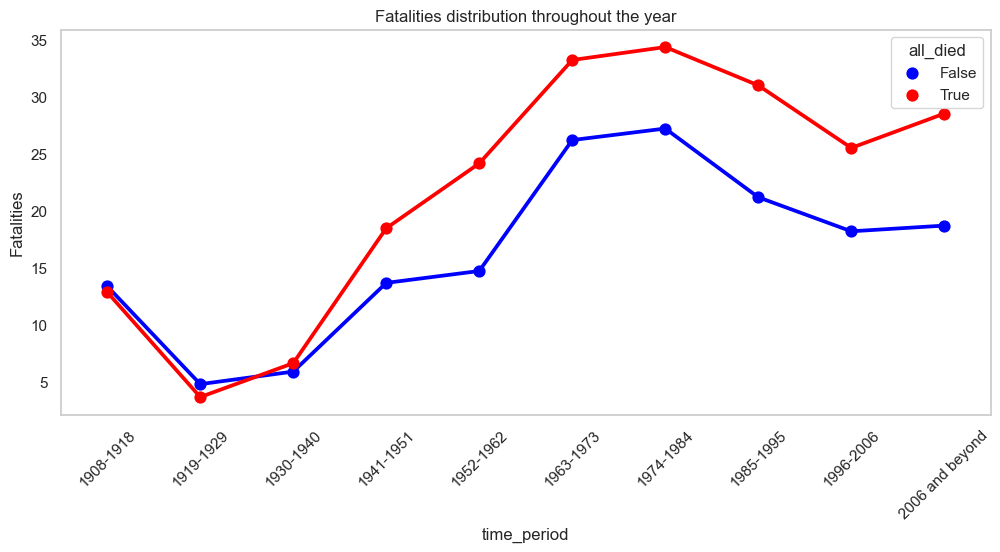

```python
sns.set(rc={'figure.figsize':(12,5)})
sns.set_style("whitegrid",{'axes.grid' : False})
hue_colors = {False:'blue',True: 'red'}
over_the_years = sns.pointplot(data = df, x = 'time_period', y = 'Fatalities', hue = 'all_died',palette = hue_colors, ci=None)

over_the_years.set_title("Fatalities distribution throughout the year")
plt.xticks(rotation=45);
```

> There appears to be a general increase in fatalities. Perhaps due to increased number of flights and larger carrying capacity of planes. As earlier seen, the larger the number onboard, the greater the fatalities. But This chart appears to have hidden the finner details.

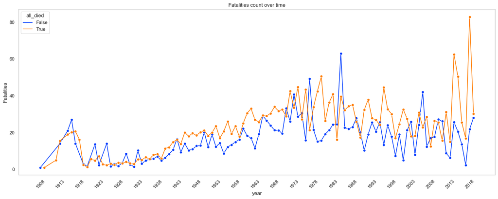

```python
sns.set(rc={'figure.figsize':(20,7)})
sns.set_style("whitegrid",{'axes.grid' : False})
year=sns.lineplot(
    data=df,
    x=df["year"],
    y="Fatalities",
    hue="all_died",
    palette="bright",
    ci = None,
    marker="o"
)
year.set_title("Fatalities count over time")
plt.xticks(np.arange(df['year'].min(), df['year'].max()+3, 5))
plt.xticks(rotation = 45)
plt.show();
```

This chart shows that they were infact some troughs through the years. But it's astonishing how the spikes are greatly increased after 2013. Perhaps they could be errors, or maybe the numbers did actually skyrocket.

### Talk about some of the relationships you observed in this part of the investigation. Were there features that strengthened each other in terms of looking at your feature(s) of interest?

> Overall, in the event of an accident, the accident is more likely to claim everybody onboard. Fatalities appear to be seasonal and follow an upward trend.

### Were there any interesting or surprising interactions between features?

> The evenings had high number of fatalities,and the fatality count has more than doubled over the years.